# Assignment 6 -- Clustering

### Task 6.1a:

Run the algorithm for different numbers of clusters ($k$ = 3, 4, 5, 6 and 7) using the mean to compute the centers of the clusters.

For each $k$, plot the original labels and the results after convergence. Report also the final loss.

- What do you observe?
- How does the final loss change using different $k$? Why?
- Do you get the same results if you run again? Why?
- **TODO:** Code and markdown

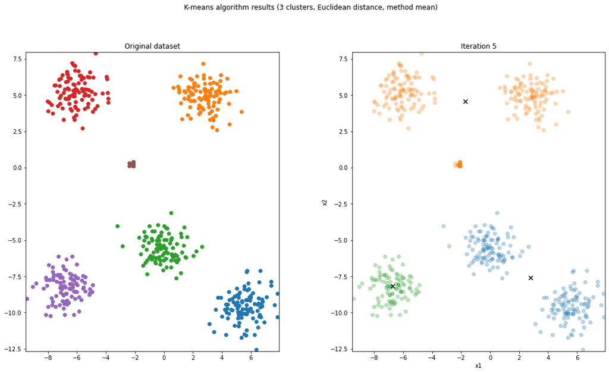

```
Final loss: 7702.731491900494
```

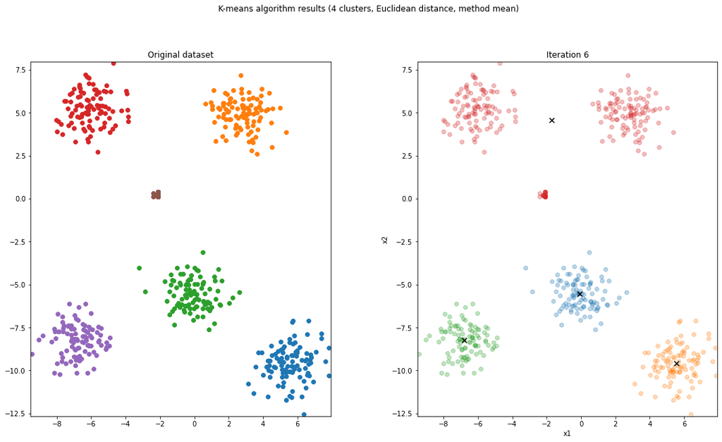

```
Final loss: 5327.719585229928
```

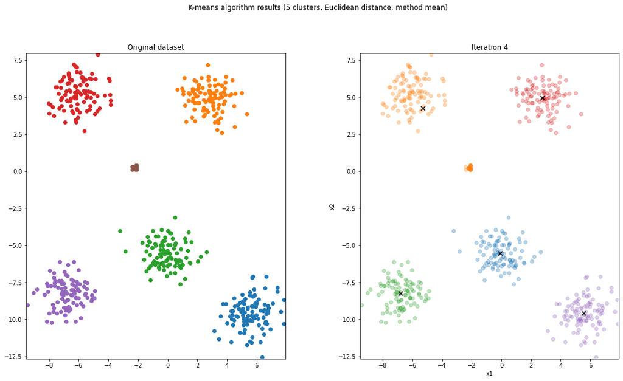

```
Final loss: 1685.6908061741194
```

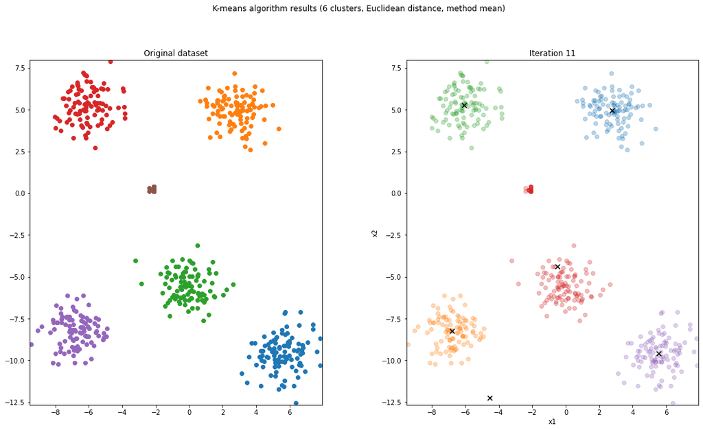

```
Final loss: 1627.6013977382427
```

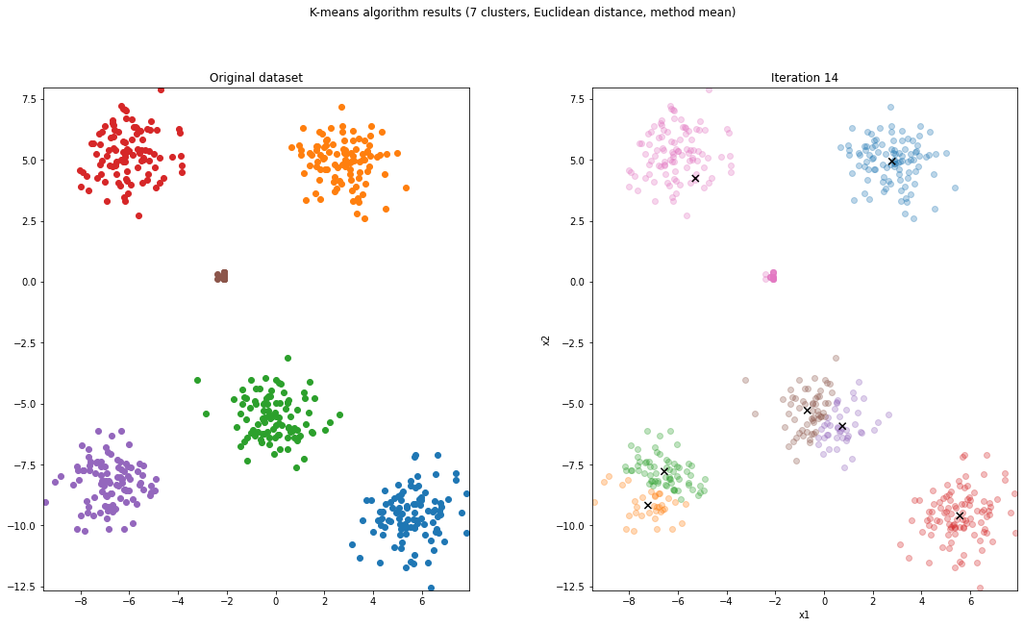

```
Final loss: 1571.1722475579384
```

```
[(7702.731491900494,
  array([20321.03467225, 12958.11950854, 10542.9065467 ,  7712.14344913,
          7702.7314919 ])),
 (5327.719585229928,
  array([29156.6242422 , 13664.48486302, 11792.11909058,  7985.63904647,
          5466.83351247,  5327.71958523])),
 (1685.6908061741194,
  array([11777.83301745,  2344.35377265,  1713.15966883,  1685.69080617])),
 (1627.6013977382427,
  array([8604.67488067, 4176.91357483, 3844.00208205, 3415.04948747,
         3239.05957707, 3158.00710264, 2998.83064848, 2606.2904608 ,
         1840.47107143, 1628.96212454, 1627.60139774])),
 (1571.1722475579384,
  array([12232.27429511,  5103.02807621,  4737.60377661,  4696.24427841,
          4689.82516859,  4681.09427216,  4639.46439101,  4072.57831427,
          1829.6903776 ,  1573.11177766,  1571.54293797,  1571.33785192,
          1571.20531162,  1571.17224756]))]
```

```python
[run(k, 'Euclidean', 'plot_convergence', 'mean') for k in range(3, 8)]
```

**What do you observe?**

For $k$s smaller than the actual number of clusters we can observe that the calculated cluster mean is usually inbetween two or more clusters (trying to minimize the loss)

Depending on the random initialisation we can also see that for bigger $k$s dummy clusters exist. Those are clusters that have no elements assigned to them yet have to exist to satisfy the number of clusters constraint.

Also on average the number of iteraions is slightly higher for bigger $k$.

**How does the final loss change using different $k$? Why?**

Ideally, the loss plotted over the number of clusters should look like an exponentially decreasing function.

For small $k$s the loss is - as to be expected - very high and it decreases with the number of clusters.

Depending on the random initialisation, however there are occasions where clusters are assigned very poorly, ruining that sort of pattern.

Higher $k$ will (with respect to random initialisation) always yield better results, since clusters can be fit more tightly. Cluster centers that "make no sense" will just become dummy clusters and do not contribute negatively to the overall loss.

**Do you get the same results if you run again? Why?**

No, depending on random initialisation the results will vary gravely.

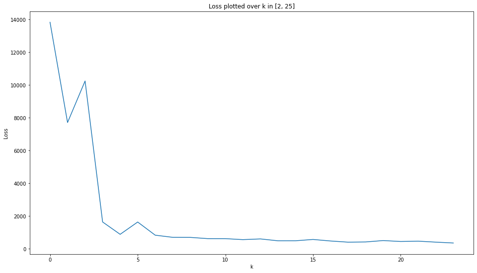

```python
low, high = 2, 25

plt.figure(figsize=(16, 9))
plt.plot(np.asarray([run(k, 'Euclidean', 'none', 'mean') for k in range(low, high + 1)])[:, 0])
plt.title(f'Loss plotted over k in [{low}, {high}]')
plt.ylabel('Loss')
plt.xlabel('k')
plt.show()
```

### Task 6.1b:

For $k=5$, plot cluster assignments and loss value after each iteration.

- What do you observe?
- **TODO:** Code and markdown

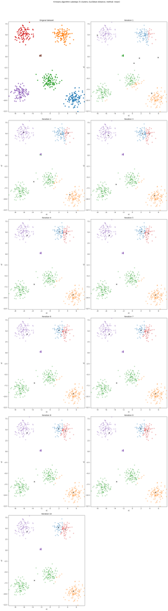

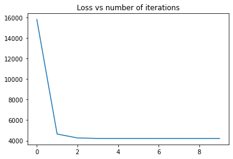

```
Final loss: 4211.686112667632
```

```
(4211.686112667632,
 array([15794.5976644 ,  4643.43975956,  4264.14816517,  4216.32931158,
         4213.7380877 ,  4213.10649757,  4212.47749446,  4211.85883029,
         4211.82040956,  4211.68611267]))
```

```python
run(5, 'Euclidean', 'plot_all', 'mean')
```

### Task 6.1c:

This task will show how two different methods of computing the center (mean and median) affect the loss during iterations. To that end, run the algorithm and store the evolution of the loss per iteration for both methods.

Because the $k$-means algorithm is very sensitive to the initialization of the centers, repeat the process 100 times (100 trials) -- 1000 if you have the computing power --, and compute the loss average over all trials for each iteration and each method. To take into account that each trial might need a different number of iterations to converge. In such a case, pad the sequence with the converged value (the last value).

Plot the average loss versus iteration number for both the mean and the median method, using $k$ = 2, 5 and 8.

- What do you observe?
- **TODO:** Code and markdown

```python
def run_n_iter(k, distance_metric, center_metric, n_iter):
    result = [run(k, distance_metric, 'none', center_metric) for _ in range(n_iter)]
    # keep only loss-list
    return np.array(result)[:, 1]


def compare(k, k_mean, k_medi):
    max_iter = max(max(map(lambda elem: len(elem), k_mean)), max(map(lambda elem: len(elem), k_medi)))

    def nan_pad(array):
        for i in range(len(array)):
            array[i] = np.pad(array[i], (0, max_iter - len(array[i])), 'constant', constant_values=array[i][-1])
        # for numpy to treat it as float matrix and not an array of sequences
        temp = np.zeros((len(array), max_iter))
        for i in range(len(array)):
            temp[i] = array[i]
        return temp

    k_mean = nan_pad(k_mean)
    k_medi = nan_pad(k_medi)

    avg_mean = np.mean(k_mean, axis=0)
    avg_medi = np.mean(k_medi, axis=0)

    plt.figure(figsize=(16, 9))
    plt.plot(range(max_iter), avg_mean, label='Mean')
    plt.plot(range(max_iter), avg_medi, label='Median')
    plt.title(f'K={k}')
    plt.ylabel('loss')
    plt.xlabel('iteration')
    plt.legend()
    plt.xticks(range(max_iter), range(max_iter))
    plt.show()
```

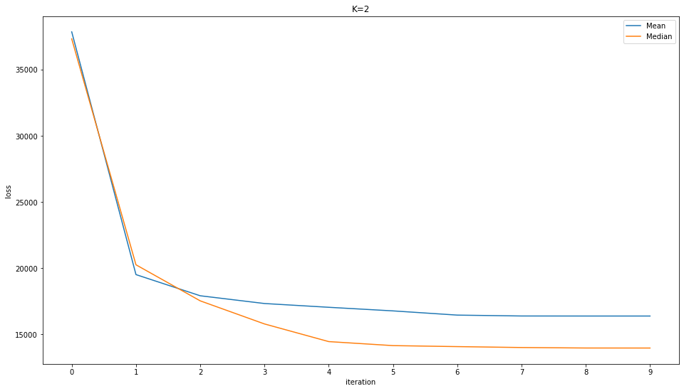

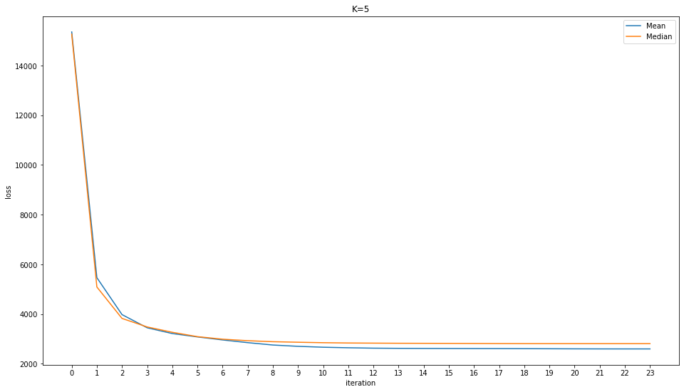

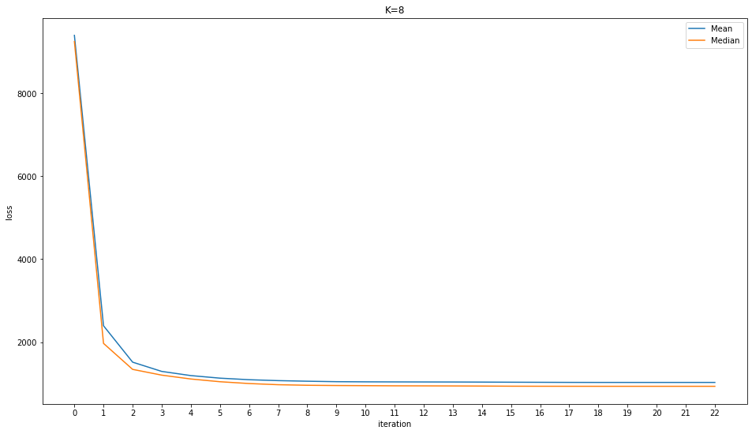

```python
n_samples = 1000

for k in (2, 5, 8):
    compare(k,
            run_n_iter(k, 'Euclidean', 'mean', n_samples),
            run_n_iter(k, 'Euclidean', 'median', n_samples))
```

**What do you observe?**

For small `k` the median loss yields better results overall. The algorithm converges faster.

For medium `k` the mean loss yields better results overall. The algorithm converges visibly slower than for small `k`.

For big `k` the median loss yields better results overall again.

We can observe a trend of finding lower losses again (as was to be expected). Also the median is less sensitive to outliers, which in the case of `k=5` is the reason why it performs worse.

### Question 6.2 (40 points):

Use the data given in `cluster1.csv`, `cluster2.csv`, `cluster3.csv` and `cluster4.csv` to compare affinity propagation clustering with $k$-means clustering. Omit the third column of each data set since it contains the labels. Use $k = 2,3,4$ for $k$-means and plot your results.

For affinity propagation you can use `AffinityPropagation` from `sklearn.cluster`. Use the default method `affinity = euclidean` (note that this is the negative squared Euclidean distance). For the preference, try the negative squared minimum, negative squared median and negative squared maximum of the similarity matrix (which is computed using the negative squared Euclidean distance).

For the $k$-means algorithm you can either use your own implementation from Exercise 6.1 or use `KMeans` from `sklearn.cluster`. In any case, keep using the (standard) Euclidean distance.

Use the provided labels to determine which algorithm and which number of clusters give better results on a specific data set and explain why one algorithm might have an advantage over the other one.

- Which method is faster?
- Which method performs best in each dataset?
- Is any dataset not "solved" by the $k$-means or Affinity Propagation? Why? Which parameters could be modified for improvement?
- **TODO:** Code and markdown

```python
from sklearn.cluster import AffinityPropagation
from sklearn.cluster import KMeans
```

```python
data_sets = []
for i in range(1, 5):
    d = np.loadtxt(f'cluster{i}.csv', delimiter=',', skiprows=1)
    data_sets.append((d[:, :-1], d[:, -1]))
```

```python
def compare_ap_km(aff_prop, X, y):
    ap = aff_prop.fit_predict(X)
    km = [KMeans(k).fit_predict(X) for k in (2, 3, 4)]

    plot_dataset(X, y, title='Original Data', include_legend=True)
    plot_dataset(X, ap, title='Affinity Propagation')
    for km_fit, k in zip(km, (2, 3, 4)):
        plot_dataset(X, km_fit, title=f'KMeans: k={k}', include_legend=True)
```

```
DATASET 1
```

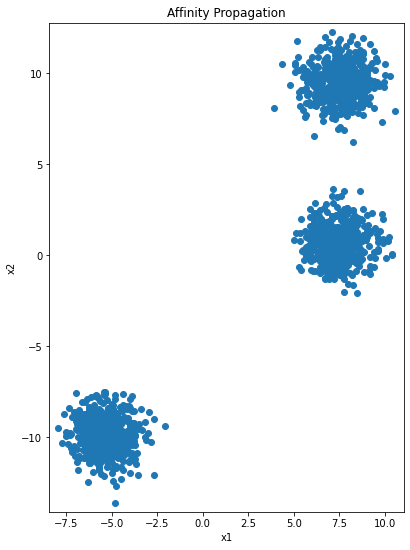

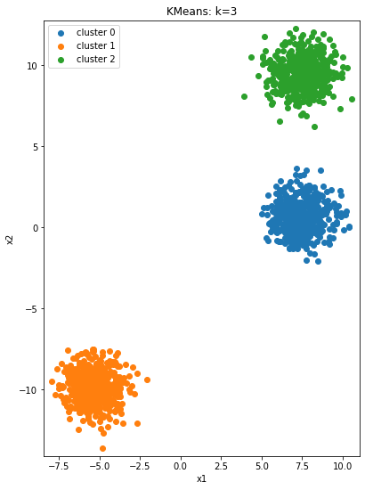

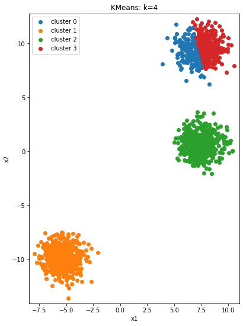

```
DATASET 2
```

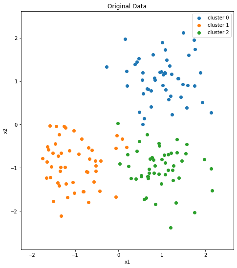

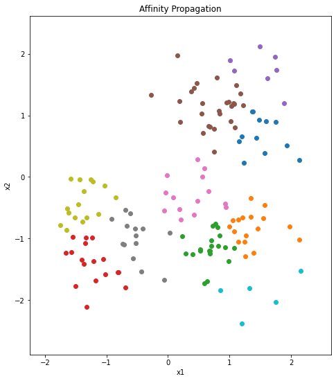

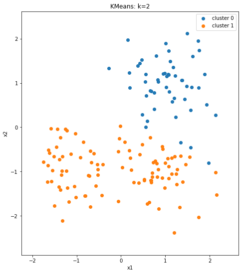

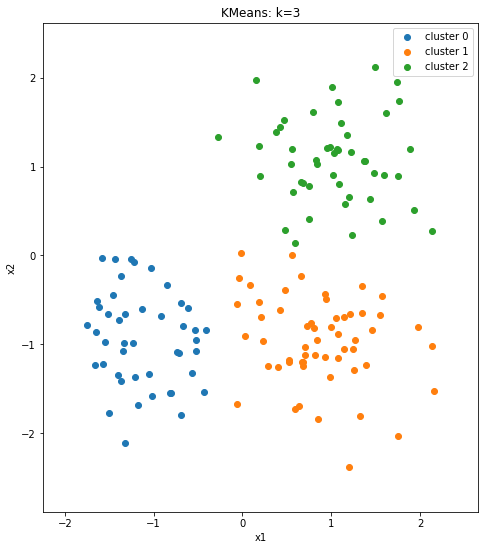

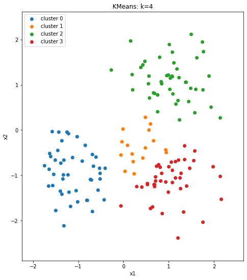

```
DATASET 3
```

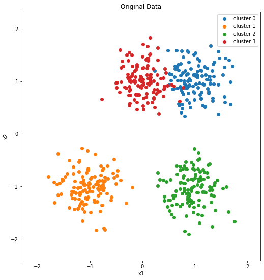

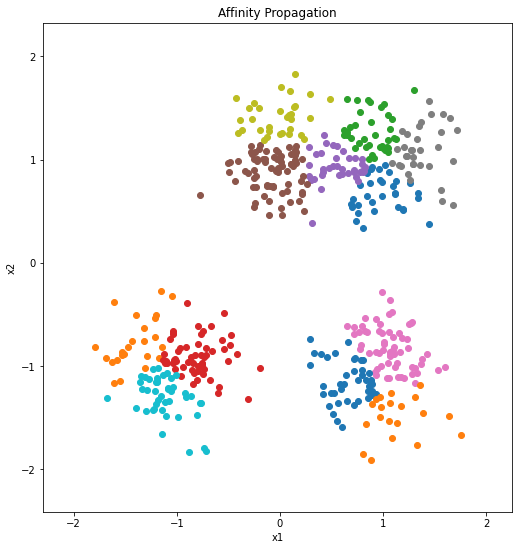

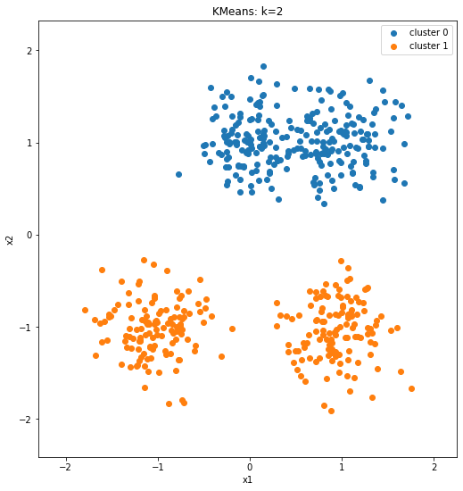

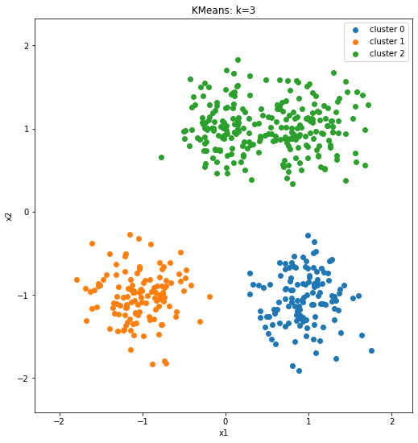

[6 more figures not shown]

```python
a = AffinityPropagation()
for i, entry in enumerate(data_sets, 1):
    print(f'DATASET {i}')
    compare_ap_km(a, entry[0], entry[1])
```

[output not shown]

**Which method is faster?** KMeans is a lot faster, since in our case we calculate a lot less clusters. In general AP is very slow to compute.